# Cyclistic Case Study

Gastón Ariel Peppino

28th June, 2022

# **Introduction**

Cyclistic, the bike sharing company would like us to find how annual members and casual riders use their service differently. In base of that premise, I’ll analyze their latest yearly dataset to gain insights that would help us convince casual riders into becoming annual members. To make it possible they want to use this information to make a decision on how to use digital media for this purpose.

## **Setting the environment**

Loading the necessary packages and then import the data.

```r
library(tidyverse)
library(janitor)
library(lubridate)
library(EnvStats)
library(outliers)
```

Note: “Tidyverse” will help us with data importing and wrangling. “Lubridate” for date functions and “outliers” and “EnvStats” to find outliers.

## **Step 1: Collecting the Data**

```r
m5_2021 <- read.csv("202105-divvy-tripdata.csv")
m6_2021 <- read.csv("202106-divvy-tripdata.csv")
m7_2021 <- read.csv("202107-divvy-tripdata.csv")
m8_2021 <- read.csv("202108-divvy-tripdata.csv")
m9_2021 <- read.csv("202109-divvy-tripdata.csv")
m10_2021 <- read.csv("202110-divvy-tripdata.csv")
m11_2021 <- read.csv("202111-divvy-tripdata.csv")
m12_2021 <- read.csv("202112-divvy-tripdata.csv")
m1_2022 <- read.csv("202201-divvy-tripdata.csv")
m2_2022 <- read.csv("202202-divvy-tripdata.csv")
m3_2022 <- read.csv("202203-divvy-tripdata.csv")
m4_2022 <- read.csv("202204-divvy-tripdata.csv")
m5_2022 <- read.csv("202205-divvy-tripdata.csv")
```

## **Step 2 : Wrangling data and combining into one set**

First, let’s inspect the datasets with the summary function

```r
summary(m5_2021)
```

```
##    ride_id          rideable_type       started_at          ended_at
##  Length:531633      Length:531633      Length:531633      Length:531633
##  Class :character   Class :character   Class :character   Class :character
##  Mode  :character   Mode  :character   Mode  :character   Mode  :character
##
##
##
##
##  start_station_name start_station_id   end_station_name   end_station_id
##  Length:531633      Length:531633      Length:531633      Length:531633
##  Class :character   Class :character   Class :character   Class :character
##  Mode  :character   Mode  :character   Mode  :character   Mode  :character
##
##
##
##
##    start_lat       start_lng         end_lat         end_lng
##  Min.   :41.65   Min.   :-87.78   Min.   :41.56   Min.   :-87.85
##  1st Qu.:41.88   1st Qu.:-87.66   1st Qu.:41.88   1st Qu.:-87.66
##  Median :41.90   Median :-87.64   Median :41.90   Median :-87.64
##  Mean   :41.90   Mean   :-87.64   Mean   :41.90   Mean   :-87.64
##  3rd Qu.:41.93   3rd Qu.:-87.63   3rd Qu.:41.93   3rd Qu.:-87.63
##  Max.   :42.07   Max.   :-87.52   Max.   :42.09   Max.   :-87.52
##                                   NA's   :452     NA's   :452
##  member_casual
##  Length:531633
##  Class :character
##  Mode  :character
##
##
##
##
```

Each dataset has 13 columns and around 100k and 700k observations. Note: In this document only one summary is shown so that the notebook doesn’t get cluttered.

Next, with the the following function of the “janitor” package I’ll check if the data frames have matching columns:

```r
compare_df_cols_same(m5_2021,m6_2021,m7_2021,m8_2021,m9_2021,m10_2021,
                     m11_2021,m12_2021,m1_2022,m2_2022,m3_2022,m4_2022,m5_2022)
```

```
## [1] TRUE
```

The result being “TRUE” indicates that the data frames have matching column names and data types.

The “rideable_type” and “ride_id” columns data types should be “character” so they can stack correctly.

```r
m5_2021 <- mutate(m5_2021, ride_id = as.character(ride_id),
                  rideable_type = as.character(rideable_type))
```

All data frames will be united into a single one, so they can be analyzed all at once:

```r
all_trips <- bind_rows(m5_2021,m6_2021,m7_2021,m8_2021,m9_2021,m10_2021,
                       m11_2021,m12_2021,m1_2022,m2_2022,m3_2022,m4_2022,
                       m5_2022)
```

Longitude and latitude variables will be removed, since they are not needed for the analysis we are trying to conduct.

```r
all_trips <- all_trips %>%
  select(-c(start_lat, start_lng, end_lat, end_lng))
```

## **Step 3 : Cleaning and adding data for analysis**

Let’s have a quick look on how our new data frame is conformed.

```r
summary(all_trips)
```

```
##    ride_id          rideable_type       started_at          ended_at
##  Length:6392409     Length:6392409     Length:6392409     Length:6392409
##  Class :character   Class :character   Class :character   Class :character
##  Mode  :character   Mode  :character   Mode  :character   Mode  :character
##  start_station_name start_station_id   end_station_name   end_station_id
##  Length:6392409     Length:6392409     Length:6392409     Length:6392409
##  Class :character   Class :character   Class :character   Class :character
##  Mode  :character   Mode  :character   Mode  :character   Mode  :character
##  member_casual
##  Length:6392409
##  Class :character
##  Mode  :character
```

Adding new variables listing date, year, month and day of each ride so we have additional opportunities to aggregate the data

```r
all_trips$date <- as.Date(all_trips$started_at) ## yy-mm-dd format
all_trips$month <- format(as.Date(all_trips$date), "%m")
all_trips$day <- format(as.Date(all_trips$date), "%d")
all_trips$year <- format(as.Date(all_trips$date), "%Y")
all_trips$day_of_week <- format(as.Date(all_trips$date), "%A")
```

Adding a “ride_length” column, by calculating the difference in the date between “ended_at” and “started_at” This new variable will have its value in seconds

```r
all_trips$ride_length <- difftime(all_trips$ended_at, all_trips$started_at)
```

Inspecting the new structure

```r
str(all_trips)
```

```
## 'data.frame':    6392409 obs. of  15 variables:
##  $ ride_id           : chr  "C809ED75D6160B2A" "DD59FDCE0ACACAF3" "0AB83CB88C43EFC2" "7881AC6D39110C60" ...
##  $ rideable_type     : chr  "electric_bike" "electric_bike" "electric_bike" "electric_bike" ...
##  $ started_at        : chr  "2021-05-30 11:58:15" "2021-05-30 11:29:14" "2021-05-30 14:24:01" "2021-05-30 14:25:51" ...
##  $ ended_at          : chr  "2021-05-30 12:10:39" "2021-05-30 12:14:09" "2021-05-30 14:25:13" "2021-05-30 14:41:04" ...
##  $ start_station_name: chr  "" "" "" "" ...
##  $ start_station_id  : chr  "" "" "" "" ...
##  $ end_station_name  : chr  "" "" "" "" ...
##  $ end_station_id    : chr  "" "" "" "" ...
##  $ member_casual     : chr  "casual" "casual" "casual" "casual" ...
##  $ date              : Date, format: "2021-05-30" "2021-05-30" ...
##  $ month             : chr  "05" "05" "05" "05" ...
##  $ day               : chr  "30" "30" "30" "30" ...
##  $ year              : chr  "2021" "2021" "2021" "2021" ...
##  $ day_of_week       : chr  "Sunday" "Sunday" "Sunday" "Sunday" ...
##  $ ride_length       : 'difftime' num  744 2695 72 913 ...
##   ..- attr(*, "units")= chr "secs"
```

```r
is.factor(all_trips$ride_length)
```

```
## [1] FALSE
```

```r
all_trips$ride_length <- as.numeric(as.character(all_trips$ride_length))
is.numeric(all_trips$ride_length)
```

```
## [1] TRUE
```

Some bikes were taken by Cyclistic employees to their headquarters for quality revisions (these cases have the variable value “start_station_name” = “HQ QR”). Also, any rows having a negative “ride_length” value should be deleted, since those would be erroneous. A new data frame “all_trips_v2” will be conformed with the cleaned data:

```r
all_trips_v2 <- all_trips[!(all_trips$start_station_name == "HQ QR" |
                              all_trips$ride_length < 0),]
```

## **Step 4 : Conducting the analysis**

To determine the difference in use between casual riders and members, the variables that are relevant to conducting the analysis are the ones that determine how much time they ride, how many times a day and what types of bikes they use. Those variables correspond to the columns “ride_length”, “rideable_type” and determining the amount of rides, based on the “started_at” column.

A descriptive analysis on “ride_length”

```r
summary(all_trips_v2$ride_length)
```

```
##    Min. 1st Qu.  Median    Mean 3rd Qu.    Max.
##       0     386     691    1268    1259 3356649
```

These values will be compared between casual riders and members

```r
aggregate(all_trips_v2$ride_length ~ all_trips_v2$member_casual, FUN = mean)
```

```
##   all_trips_v2$member_casual all_trips_v2$ride_length
## 1                     casual                1874.9993
## 2                     member                 790.0134
```

```r
aggregate(all_trips_v2$ride_length ~ all_trips_v2$member_casual, FUN = median)
```

```
##   all_trips_v2$member_casual all_trips_v2$ride_length
## 1                     casual                      932
## 2                     member                      553
```

```r
aggregate(all_trips_v2$ride_length ~ all_trips_v2$member_casual, FUN = min)
```

```
##   all_trips_v2$member_casual all_trips_v2$ride_length
## 1                     casual                        0
## 2                     member                        0
```

```r
aggregate(all_trips_v2$ride_length ~ all_trips_v2$member_casual, FUN = max)
```

```
##   all_trips_v2$member_casual all_trips_v2$ride_length
## 1                     casual                  3356649
## 2                     member                    93594
```

The maximum values of ride_length for casual riders are around 900 hours (3M seconds), these values could be outliers. Since no normal bike ride should last that long. Errors might have been introduce in the data collection process or reasons such as riders not returning their bikes for several days.

This would be the distribution of the data frame values:

```r
library(scales)
```

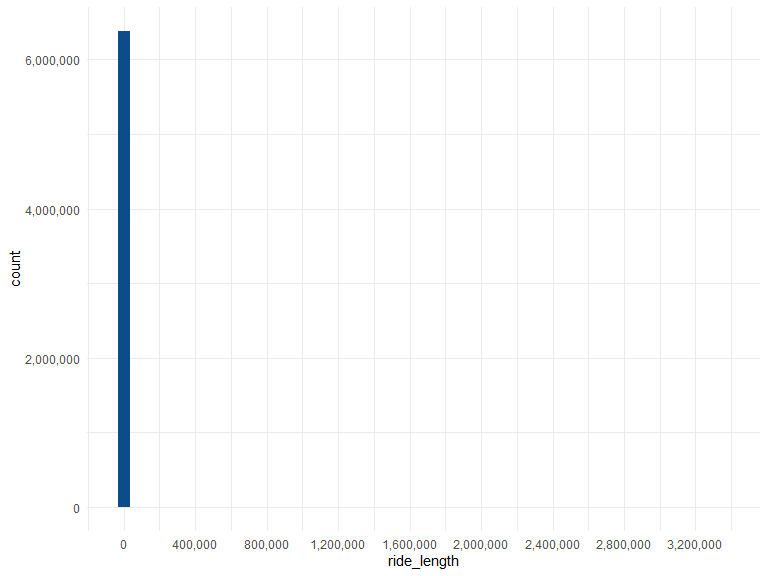

```r
ggplot(all_trips_v2) + aes(x= ride_length) +
  geom_histogram(bins= 50L, fill= "#0c4c8a")+
  theme_minimal() + scale_x_continuous(n.breaks = 12,labels= comma) +
  scale_y_continuous(labels= comma)
```

We’ll search for outliers using a 99 percentile

```r
upper_bound <- quantile(all_trips_v2$ride_length, 0.99)
upper_bound
```

```
##  99%
## 7522
```

The maximum value would be 7522. Next we create another data frame removing values for ride length greater than 7522.

```r
all_trips_v3 <- all_trips_v2[-which(all_trips_v2$ride_length > 7522),]
```

Conducting Rosner’s test for outliers :

```r
outlier_test <- rosnerTest(all_trips_v3$ride_length, k=5)
outlier_test[7]
```

```
## $n.outliers
## [1] 5
```

The five maximum values are outliers, so we’ll now try with a 98 percentile

```r
upper_bound <- quantile(all_trips_v2$ride_length, 0.98)
upper_bound
```

```
##  98%
## 5337
```

The maximum value for ride length would be 5337 We create the new data frame and conduct Rosner’s test again :

```r
all_trips_v3 <- all_trips_v2[-which(all_trips_v2$ride_length > 5337),]
outlier_test <- rosnerTest(all_trips_v3$ride_length, k=5)
outlier_test[7]
```

```
## $n.outliers
## [1] 0
```

Now, the highest 5 values are not considered outliers according to Rosner’s test.

The following histogram shows the current distribution of values:

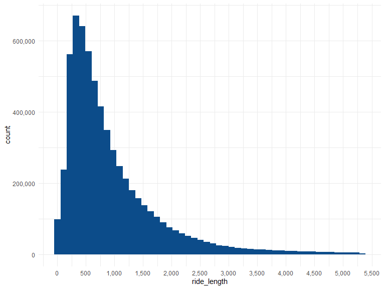

```r
ggplot(all_trips_v3) + aes(x= ride_length) +
  geom_histogram(bins= 50L, fill= "#0c4c8a")+
  theme_minimal() + scale_x_continuous(n.breaks = 12,labels= comma) +
  scale_y_continuous(labels= comma)
```

We can now compare statistics with the new data frame. Now adding the average ride time each day of the week for both type of users :

```r
aggregate(all_trips_v3$ride_length ~ all_trips_v3$member_casual, FUN = mean)
```

```
##   all_trips_v3$member_casual all_trips_v3$ride_length
## 1                     casual                1210.1463
## 2                     member                 736.6561
```

```r
aggregate(all_trips_v3$ride_length ~ all_trips_v3$member_casual, FUN = median)
```

```
##   all_trips_v3$member_casual all_trips_v3$ride_length
## 1                     casual                      891
## 2                     member                      551
```

```r
aggregate(all_trips_v3$ride_length ~ all_trips_v3$member_casual, FUN = min)
```

```
##   all_trips_v3$member_casual all_trips_v3$ride_length
## 1                     casual                        0
## 2                     member                        0
```

```r
aggregate(all_trips_v3$ride_length ~ all_trips_v3$member_casual, FUN = max)
```

```
##   all_trips_v3$member_casual all_trips_v3$ride_length
## 1                     casual                     5337
## 2                     member                     5337
```

```r
aggregate(all_trips_v3$ride_length ~ all_trips_v3$member_casual +
            all_trips_v3$day_of_week, FUN = mean)
```

```
##    all_trips_v3$member_casual all_trips_v3$day_of_week all_trips_v3$ride_length
## 1                      casual                   Friday                1146.8847
## 2                      member                   Friday                 718.7563
## 3                      casual                   Monday                1226.3553
## 4                      member                   Monday                 716.3951
## 5                      casual                 Saturday                1308.9083
## 6                      member                 Saturday                 819.4285
## 7                      casual                   Sunday                1353.5212
## 8                      member                   Sunday                 827.2354
## 9                      casual                 Thursday                1086.7980
## 10                     member                 Thursday                 703.7752
## 11                     casual                  Tuesday                1093.7776
## 12                     member                  Tuesday                 693.0182
## 13                     casual                Wednesday                1086.7296
## 14                     member                Wednesday                 703.0079
```

Note that the days of the week are out of order, let’s correct that :

```r
all_trips_v3$day_of_week <- ordered(all_trips_v3$day_of_week,
                                    levels= c("Sunday", "Monday", "Tuesday",
                                              "Wednesday", "Thursday", "Friday",
                                              "Saturday"))
```

Running the previous analysis once more :

```r
aggregate(all_trips_v3$ride_length ~ all_trips_v3$member_casual +
            all_trips_v3$day_of_week, FUN = mean)
```

```
##    all_trips_v3$member_casual all_trips_v3$day_of_week all_trips_v3$ride_length
## 1                      casual                   Sunday                1353.5212
## 2                      member                   Sunday                 827.2354
## 3                      casual                   Monday                1226.3553
## 4                      member                   Monday                 716.3951
## 5                      casual                  Tuesday                1093.7776
## 6                      member                  Tuesday                 693.0182
## 7                      casual                Wednesday                1086.7296
## 8                      member                Wednesday                 703.0079
## 9                      casual                 Thursday                1086.7980
## 10                     member                 Thursday                 703.7752
## 11                     casual                   Friday                1146.8847
## 12                     member                   Friday                 718.7563
## 13                     casual                 Saturday                1308.9083
## 14                     member                 Saturday                 819.4285
```

Determining the number of rides based on the “started_at” column.

Number of rides per day :

```r
num_rides_count <- all_trips_v3 %>%
  mutate(weekday= wday(started_at, label= TRUE)) %>% ## creates weekday field
  group_by(member_casual, weekday) %>%
  summarize(number_of_rides= n(), average_duration= mean(ride_length)) %>%
  arrange(member_casual, weekday)
num_rides_count
```

```
## # A tibble: 14 × 4
## # Groups:   member_casual [2]
##    member_casual weekday number_of_rides average_duration
##    <chr>         <ord>             <int>            <dbl>
##  1 casual        Sun              503166            1354.
##  2 casual        Mon              321822            1226.
##  3 casual        Tue              295825            1094.
##  4 casual        Wed              299533            1087.
##  5 casual        Thu              320994            1087.
##  6 casual        Fri              377112            1147.
##  7 casual        Sat              582058            1309.
##  8 member        Sun              434630             827.
##  9 member        Mon              506186             716.
## 10 member        Tue              556855             693.
## 11 member        Wed              550624             703.
## 12 member        Thu              536139             704.
## 13 member        Fri              494002             719.
## 14 member        Sat              485502             819.
```

Types of bikes used by user type :

```r
bike_type_count <- table(all_trips_v3$rideable_type, all_trips_v3$member_casual)
bike_type_count
```

```
##
##                  casual  member
##   classic_bike  1305875 2159537
##   docked_bike    275027       0
##   electric_bike 1119608 1404401
```

Average length of the rides per day :

```r
ride_length_count <- aggregate(all_trips_v3$ride_length ~ all_trips_v3$member_casual +
                      all_trips_v3$day_of_week, FUN= mean)
ride_length_count
```

```
##    all_trips_v3$member_casual all_trips_v3$day_of_week all_trips_v3$ride_length
## 1                      casual                   Sunday                1353.5212
## 2                      member                   Sunday                 827.2354
## 3                      casual                   Monday                1226.3553
## 4                      member                   Monday                 716.3951
## 5                      casual                  Tuesday                1093.7776
## 6                      member                  Tuesday                 693.0182
## 7                      casual                Wednesday                1086.7296
## 8                      member                Wednesday                 703.0079
## 9                      casual                 Thursday                1086.7980
## 10                     member                 Thursday                 703.7752
## 11                     casual                   Friday                1146.8847
## 12                     member                   Friday                 718.7563
## 13                     casual                 Saturday                1308.9083
## 14                     member                 Saturday                 819.4285
```

## **Step 5: Exporting the results**

These summarized statistics were exported for further analysis in a spreadsheet software. The following tables and visualizations were created, that would let us arrive our conclusions.

This table contains data about the number of rides and average ride time per weekday for casual riders and members :

```r
library(DT)
datatable(num_rides_count, rownames= FALSE, filter= "top", options= list(pageLength= 7, scrollX= T))
```

| member_casual | weekday | number_of_rides | average_duration |
| --- | --- | --- | --- |
| casual | Sun | 503166 | 1353.5211997631 |
| casual | Mon | 321822 | 1226.35530821386 |
| casual | Tue | 295825 | 1093.77761514409 |
| casual | Wed | 299533 | 1086.72961576855 |
| casual | Thu | 320994 | 1086.79799310891 |
| casual | Fri | 377112 | 1146.88468942914 |
| casual | Sat | 582058 | 1308.90825484746 |
| member | Sun | 434630 | 827.235374916596 |
| member | Mon | 506186 | 716.395072167148 |
| member | Tue | 556855 | 693.018239936788 |

[output cut: 4 more lines]

[figure not shown]

[figure not shown]

Casual riders have overall higher ride duration than members, but it’s decrease through the week is more pronounced. A hypothesis would be, that casual riders, use the service for leisure activities such as sight-seen, thus taking more time in their rides. In the other hand, members would be using the service to commute to work, school or to do chores, having less distractions and a more direct route, hence the shorter ride times. Further data collection and analysis would be needed to confirm this hypothesis, such as a survey asking for what purpose clients use the service, and if they are annual members or not.

```r
library(DT)
```

This table shows us how many bikes, depending on their type, were used by both kind of clients :

```r
datatable(bike_type_count, rownames= FALSE, filter= "top", options= list(pageLength= 7, scrollX= T))
```

| Var1 | Var2 | Freq |
| --- | --- | --- |
| classic_bike | casual | 1305875 |
| docked_bike | casual | 275027 |
| electric_bike | casual | 1119608 |
| classic_bike | member | 2159537 |
| docked_bike | member | 0 |
| electric_bike | member | 1404401 |

The visualization created with the table above :

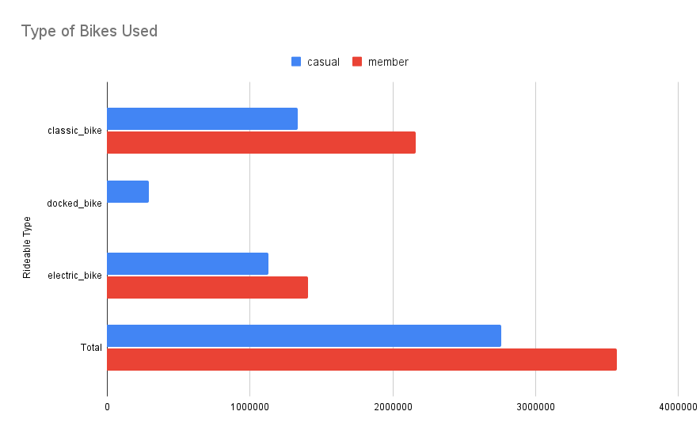

Members use more classic and electric bikes than casuals, with the total number coinciding with the total number of yearly rides. Casuals are the only ones using docked bikes. This would be due to members being able to use bikes that are not docked, and to leave them in other places than dock stations.

Recommendations will be discussed in the presentation.

Thanks for reading. If you have any questions, you can email me at iegpeppino@gmail.com